# **Actividad 2**

Equipo 3

2025-04-04

# 1 Datos Espaciales

## 1.1 Análisis de Datos Espaciales

### 1.1.1 Análisis Exploratorio de Datos Espaciales

Se analizará cómo estas variables se distribuyen espacialmente a través de los estados de México, sus patrones de clustering espacial y cómo se relacionan entre sí considerando su ubicación geográfica.

Como suele ser lo primero debe ser cargar las librerías a utilizar:

```r
library(foreign) # Importar archivos externos
library(dplyr) # Manipulación de datos
library(spdep) # Colección de funciones para crear matriz de pesos espaciales
library(tigris) # Permite trabajar con shapefiles
library(rgeoda) # Análisis de datos espaciales basado en GeoDa
library(RColorBrewer) # Ofrece varias paletas de colores
library(viridis) # Ofrece varias paletas de colores
library(ggplot2) # Para crear gráficos a partir del conjunto de datos
library(tmap) # Creación de mapas para visualizar distribuciones de datos espaciales
library(sf) # Funciones para codificar datos vectoriales espaciales
library(sp) # Clases y métodos para datos espaciales
library(spgwr) # Regresión ponderada geográficamente
library(GWmodel) # Requerido para la creación adaptativa del kernel para aplicar GWR
```

Seguidamente se procede a importar las bases de datos requeridas:

Primero leemos las bases de datos tradicionales (tablas de valores numéricos) a los diferentes niveles geográficos (espaciales) involucrados en nuestro análisis.

A nivel estatal

```r
mx_state <- read.csv("state_data.csv")
head(mx_state)
```

|  | state | year | state_id | crime_rate | unemployment | employment | business_activity | real_wage | real_ave_month_income | pop_density | lq_primary | lq_secondary | lq_tertiary | new_fdi_real_mxn | log_new_fdi_real_mxn | region_a | region_b |
| --- | --- | --- | --- | --- | --- | --- | --- | --- | --- | --- | --- | --- | --- | --- | --- | --- | --- |
| 1 | Aguascalientes | 2021 | 1057 | 6.75 | 0.04 | 0.97 | -1.90 | 361.02 | 5641.67 | 261.21 | 0.16 | 1.24 | 1.00 | 1270.03 | 3.10 | Bajio | 2 |
| 2 | Baja California | 2021 | 2304 | 84.67 | 0.01 | 0.98 | 2.47 | 388.22 | 7599.62 | 53.19 | 0.47 | 1.62 | 0.86 | 20407.81 | 4.31 | Norte | 3 |
| 3 | Baja California Sur | 2021 | 2327 | 8.52 | 0.03 | 0.97 | -2.12 | 345.57 | 8660.90 | 11.27 | 0.73 | 0.51 | 1.13 | 19022.55 | 4.28 | Occidente | 4 |
| 4 | Campeche | 2021 | 1086 | 9.22 | 0.02 | 0.98 | -2.44 | 414.48 | 5357.29 | 16.42 | 0.73 | 0.78 | 1.06 | 2390.64 | 3.38 | Sur | 5 |
| 5 | Chiapas | 2021 | 1182 | 10.01 | 0.05 | 0.97 | -2.41 | 312.37 | 6581.28 | 77.16 | 1.56 | 0.88 | 0.99 | 189.58 | 2.28 | Sur | 5 |
| 6 | Chihuahua | 2021 | 888 | 71.98 | 0.04 | 0.97 | -1.25 | 362.93 | 5708.75 | 15.30 | 0.64 | 1.97 | 0.80 | 7153.63 | 3.86 | Norte | 3 |

```r
glimpse(mx_state)
```

```
## Rows: 32
## Columns: 17
## $ state                 <chr> "Aguascalientes", "Baja California", "Baja Calif…
## $ year                  <int> 2021, 2021, 2021, 2021, 2021, 2021, 2021, 2021, …
## $ state_id              <int> 1057, 2304, 2327, 1086, 1182, 888, 1114, 933, 11…
## $ crime_rate            <dbl> 6.75, 84.67, 8.52, 9.22, 10.01, 71.98, 11.58, 4.…
## $ unemployment          <dbl> 0.04, 0.01, 0.03, 0.02, 0.05, 0.04, 0.06, 0.04, …
## $ employment            <dbl> 0.97, 0.98, 0.97, 0.98, 0.97, 0.97, 0.94, 0.94, …
## $ business_activity     <dbl> -1.90, 2.47, -2.12, -2.44, -2.41, -1.25, -2.08, …
## $ real_wage             <dbl> 361.02, 388.22, 345.57, 414.48, 312.37, 362.93, …
## $ real_ave_month_income <dbl> 5641.67, 7599.62, 8660.90, 5357.29, 6581.28, 570…
## $ pop_density           <dbl> 261.21, 53.19, 11.27, 16.42, 77.16, 15.30, 6195.…
## $ lq_primary            <dbl> 0.16, 0.47, 0.73, 0.73, 1.56, 0.64, 0.03, 0.17, …
## $ lq_secondary          <dbl> 1.24, 1.62, 0.51, 0.78, 0.88, 1.97, 0.58, 1.55, …
## $ lq_tertiary           <dbl> 1.00, 0.86, 1.13, 1.06, 0.99, 0.80, 1.14, 0.93, …
## $ new_fdi_real_mxn      <dbl> 1270.03, 20407.81, 19022.55, 2390.64, 189.58, 71…
## $ log_new_fdi_real_mxn  <dbl> 3.10, 4.31, 4.28, 3.38, 2.28, 3.86, 4.54, 3.80, …
## $ region_a              <chr> "Bajio", "Norte", "Occidente", "Sur", "Sur", "No…
## $ region_b              <int> 2, 3, 4, 5, 5, 3, 1, 3, 4, 4, 2, 5, 1, 4, 1, 4, …
```

A nivel municipal

```r
mx_mpio  <- read.csv("mpio_data.csv")
head(mx_mpio)
```

|  | clave_municipio | entidad | mpio | hogremjefmuj2015 | popnoafmed2015 | popden2020 | crimen_2018 | crimen_2019 | tasa_covid |
| --- | --- | --- | --- | --- | --- | --- | --- | --- | --- |
| 1 | 1001 | Aguascalientes | Aguascalientes | 2782.7 | 1433.7 | 811.991 | 7.36 | 8.15 | 344.852 |
| 2 | 1002 | Aguascalientes | Asientos | 2205.4 | 577.4 | 94.087 | 7.81 | 5.78 | 118.945 |
| 3 | 1003 | Aguascalientes | Calvillo | 2559.6 | 997.4 | 62.549 | 8.40 | 8.31 | 210.500 |
| 4 | 1004 | Aguascalientes | Cosio | 2117.1 | 528.3 | 131.885 | 17.86 | 0.00 | 87.481 |
| 5 | 1005 | Aguascalientes | Jesus Maria | 1989.2 | 1402.4 | 260.285 | 5.14 | 10.98 | 95.941 |
| 6 | 1006 | Aguascalientes | Pabellon de Arteaga | 2612.1 | 1023.0 | 239.019 | 4.32 | 0.00 | 216.062 |

```r
glimpse(mx_mpio)
```

```
## Rows: 2,449
## Columns: 9
## $ clave_municipio  <int> 1001, 1002, 1003, 1004, 1005, 1006, 1007, 1008, 1009,…
## $ entidad          <chr> "Aguascalientes", "Aguascalientes", "Aguascalientes",…
## $ mpio             <chr> "Aguascalientes", "Asientos", "Calvillo", "Cosio", "J…
## $ hogremjefmuj2015 <dbl> 2782.7, 2205.4, 2559.6, 2117.1, 1989.2, 2612.1, 2499.…
## $ popnoafmed2015   <dbl> 1433.7, 577.4, 997.4, 528.3, 1402.4, 1023.0, 1080.1, …
## $ popden2020       <chr> "811.991", "94.087", "62.549", "131.885", "260.285", …
## $ crimen_2018      <dbl> 7.36, 7.81, 8.40, 17.86, 5.14, 4.32, 7.33, 0.00, 4.49…
## $ crimen_2019      <dbl> 8.15, 5.78, 8.31, 0.00, 10.98, 0.00, 5.43, 0.00, 4.43…
## $ tasa_covid       <dbl> 344.852, 118.945, 210.500, 87.481, 95.941, 216.062, 1…
```

Seguidamente, se leen los archivos de las formas geométricas (geocercas) que determinarán los mapas a realizar después para visualizar los datos.

NOTA: Indispensable que en la misma carpeta que contiene el código se ubiquen los archivos con extensiones: .cpg, .dbf, .prj, .sbn, .sbx, .shx y .shp. Aunque, aparentemente el código sólo lee el archivo .shp, este tiene referencia a todos los demás, por lo que si alguno falta seguramente la ejecución del código marcará un error.

Igual que antes, esto viene a diferentes niveles de granularidad:

A nivel estado (32)

```r
mx_state_map <- st_read("mexlatlong.shp")
# mx_state_map <- read_sf("mexlatlong.shp")
```

A nivel municipio (2,456)

```r
mx_mpio_map <- st_read("Mexican Municipalities.shp")
# mx_mpio_map <- read_sf("Mexican Municipalities.shp")
```

Ahora que tenemos ambas bases de datos en el ambiente de trabajo de R, es necesario unificarlas mediante algún campo clave (OBJECTID para las geocercas y state_id para la base de datos tradicional en este caso).

```r
state_geodata <- geo_join(mx_state_map,mx_state,'OBJECTID','state_id',how='inner')
mpio_geodata  <- geo_join(mx_mpio_map,mx_mpio,'IDUNICO','clave_municipio',how='inner')
```

### 1.1.2 Análisis Exploratorio de Datos (EDA: Exploratory Data Analysis)

El Análisis exploratorio de datos es útil para detectar errores obvios o bien identificar datos atípicos o faltantes dentro de nuestra base de datos. A su vez, ayuda a obtener un mejor entendimiento de los posibles patrones dentro de la base de datos y relaciones relevantes o significativas entre las diferentes variables involucradas.

En este caso, nos enfocaremos en entender cómo la Actividad Empresarial, el Salario Real y la Inversión Extranjera Directa (Log) varían a través del espacio geográfico de México, identificando posibles clusters o patrones espaciales que puedan ser de interés.

### 1.1.3 Análisis Exploratorio de Datos Espaciales (ESDA: Exploratory Spatial Data Analysis)

El Análisis exploratorio de datos espacial involucra diferentes herramientas para visualizar los patrones espaciales existentes en la base de datos. Estos datos se pueden segregar o descomponer los patrones espaciales en diferentes elementos a lo largo del mapa, y a su vez medir la extensión de estas autocorrelaciones espaciales.

La creación de mapas siempre parte de las geocercas importadas en R mediante los archivos .shp

```r
### Basic Map Making
# plot(state_geodata)
# plot(mpio_geodata) do not run
```

Ahora unos simples ejemplos utilizando la librería ‘tmap’

Visualización a nivel estado

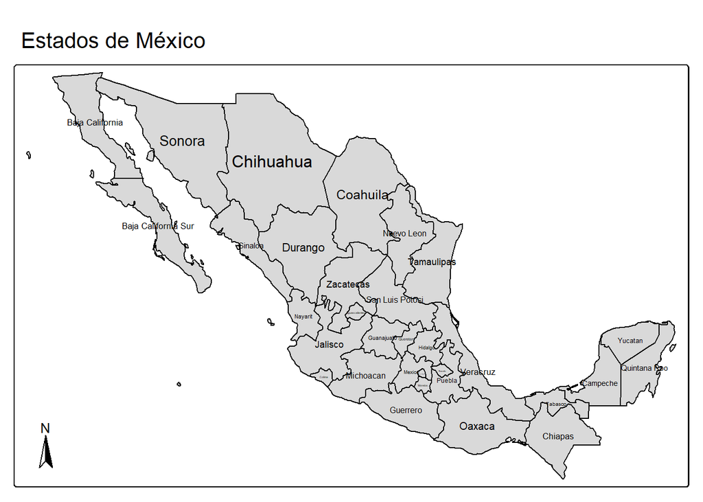

```r
tm_shape(mx_state_map) +
  tm_polygons(col = "black") +
  tm_compass(position=c("left","bottom")) +
  tm_title("Estados de México") +
  tm_text("ADMIN_NAME", size = "AREA")
```

Visualización a nivel municipio (puede tardar unos minutos en ejecutarse)

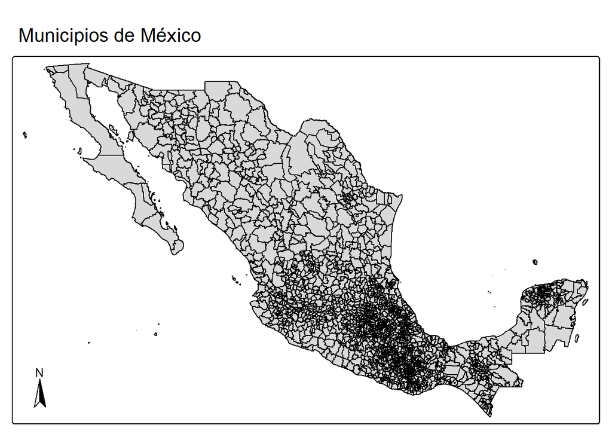

```r
tm_shape(mx_mpio_map) +
  tm_polygons(col = "black") +
  tm_compass(position=c("left","bottom")) +
  tm_title("Municipios de México")
```

Por si acaso, puede ser recomendable actualizar la librería ‘tmap’ de acuerdo a los contenidos en GitHub, esto se puede realizar utilizando los siguientes comandos

```r
## library(tmap) # Breaking News: tmap 3.x is retiring
# remotes::install_github('r-tmap/tmap')
```

Ya con la última versión pueden ejecutar el siguiente comando que abre una breve página desarrollada con la paquetería de ‘Shiny’ para visualizar diferentes opciones disponibles para las paletas de colores

```r
# tmaptools::palette_explorer()
```

Ahora sí, mezclaremos la data de las geocercas con alguna de las variables que vienen en la tabla de datos inicial para su visualización en los mapas:

Municipios de México y su falta de acceso a los Servicios de Salud

```r
tm_shape(mpio_geodata) +
  tm_polygons(col = "popnoafmed2015", palette="-cividis", style="quantile", n=8, title="Pop Percentage") +
  tm_title_out('Población sin Acceso a Servicios de Salud', position=c('right', 'top'), size=1) +
  tm_legend(position= c("left", "bottom"))
```

```
## ── tmap v3 code detected ─────────────────────────────────────────────────────────────────────────────────────────────────────────────────────────────────────────────
```

[output not shown]

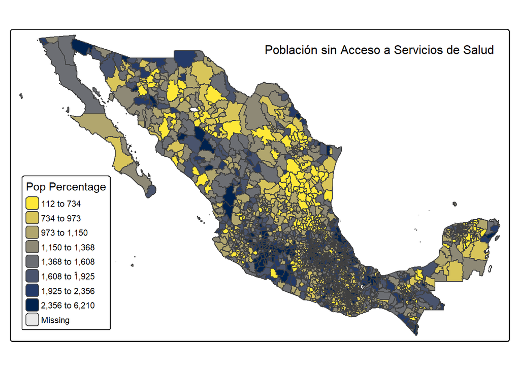

Distribución del Salario Real por Estado

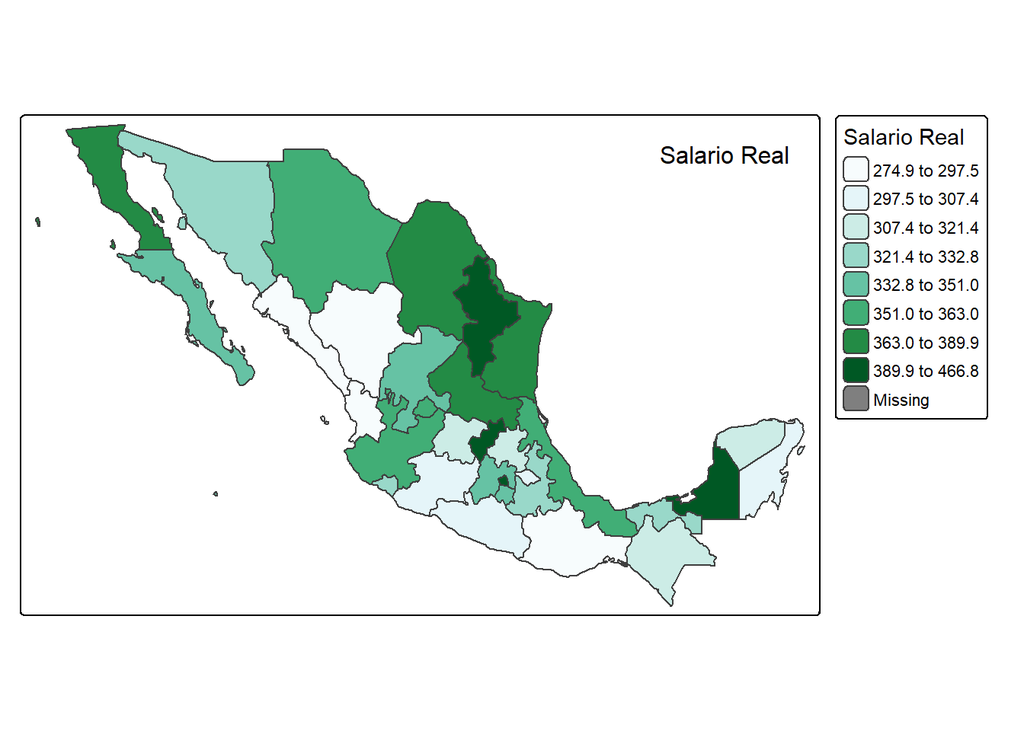

```r
tm_shape(state_geodata) +
  tm_polygons(col = "real_wage", palette="BuGn", style="quantile", n=8, title="Salario Real") +
  tm_layout(main.title= 'Salario Real',  title.position = c('right', 'top'), legend.outside = TRUE, legend.outside.position = "left", title.size = 1)
```

Distribución de la Actividad Empresarial por Estado

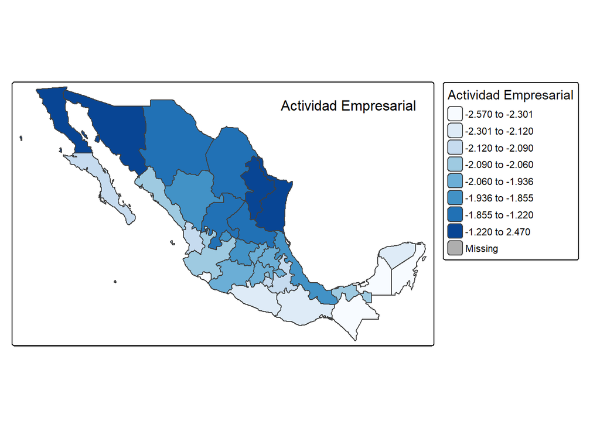

```r
tm_shape(state_geodata) +
  tm_polygons(col = "business_activity", palette="Blues", style="quantile", n=8, title="Actividad Empresarial") +
  tm_layout(main.title= 'Actividad Empresarial',  title.position = c('right', 'top'), legend.outside = TRUE, legend.outside.position = "left", title.size = 1)
```

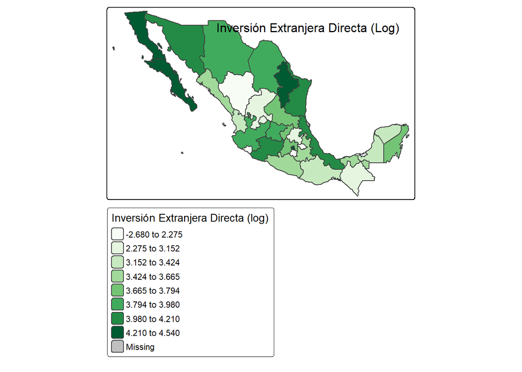

```r
tm_shape(state_geodata) +
  tm_polygons(col = "log_new_fdi_real_mxn", palette="Greens", style="quantile", n=8, title="Inversión Extranjera Directa (log)") +
  tm_layout(main.title= 'Inversión Extranjera Directa (Log)',  title.position = c('right', 'top'), legend.outside = TRUE, legend.outside.position = "left", title.size = 1)
```

### 1.1.4 Matriz de Conectividad Espacial

La matriz de conectividad espacial nos ayudará a entender las relaciones espaciales entre los estados y cómo la Actividad Empresarial, el Salario Real y la Inversión Extranjera Directa pueden estar relacionados espacialmente.

```r
swm  <- poly2nb(mx_state_map, queen=T)

summary(swm) # The average number of neighbors is 4.31
```

```
## Neighbour list object:
## Number of regions: 32
## Number of nonzero links: 138
## Percentage nonzero weights: 13.47656
## Average number of links: 4.3125
## Link number distribution:
##
## 1 2 3 4 5 6 7 8 9
## 1 6 6 6 5 2 3 2 1
## 1 least connected region:
## 31 with 1 link
## 1 most connected region:
## 8 with 9 links
```

Visualización Gráfica de la matriz de conectividad (Vecindades estilo ‘Reina’)

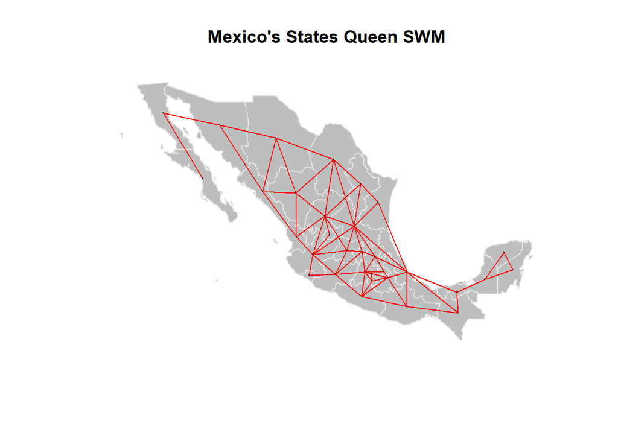

```r
sswm <- nb2listw(swm, style="W", zero.policy = TRUE)

mx_state_map_a <- as(mx_state_map, "Spatial")
mx_state_map_centroid <- coordinates(mx_state_map_a)
plot(mx_state_map_a,border="blue",axes=FALSE,las=1, main="Mexico's States Queen SWM")
plot(mx_state_map_a,col="grey",border=grey(0.9),axes=T,add=T)
plot(sswm,coords=mx_state_map_centroid,pch=19,cex=0.1,col="red",add=T)
```

### 1.1.5 Análisis de Autocorrelación Espacial

#### 1.1.5.1 Índice Global de Moran

```r
moran_business <- moran.test(state_geodata$business_activity, sswm)           # Global Moran's I test para la Actividad Empresarial
moran_wage <- moran.test(state_geodata$real_wage, sswm)                  # Global Moran's I test para el Salario Real
moran_fdi <- moran.test(state_geodata$log_new_fdi_real_mxn, sswm)      # Global Moran's I test para la IED
```

Presentación de resultados en formato tabla

```r
# Extraer los valores del índice de Moran y los p-values
moran_values <- c(moran_business$estimate[1], moran_wage$estimate[1], moran_fdi$estimate[1])
p_values <- c(moran_business$p.value, moran_wage$p.value, moran_fdi$p.value)

# Generar indicadores de significancia
significance <- sapply(p_values, function(p) {
  if (p < 0.001) return("***")
  else if (p < 0.01) return("**")
  else if (p < 0.05) return("*")
  else return("NS")
})

# Crear la tabla de resultados
tabla_moran <- data.frame(
  Variable = c("Actividad Empresarial", "Salario Real", "Inversión Extranjera Directa (Log)"),
  Índice_Moran = round(moran_values, 4),
  Valor_p = round(p_values, 4),
  Significancia = significance
)

tabla_moran
```

| Variable | Índice_Moran | Valor_p | Significancia |
| --- | --- | --- | --- |
| Actividad Empresarial | 0.1842 | 0.0046 | ** |
| Salario Real | 0.0725 | 0.1939 | NS |
| Inversión Extranjera Directa (Log) | -0.0185 | 0.4401 | NS |

- Actividad Empresarial:
  - Estadístico de Moran: 0.184 (p-valor: 0.004)
  - Autocorrelación espacial positiva significativa
  - Estados con niveles similares de actividad empresarial tienden a agruparse espacialmente
- Salario Real:
  - Estadístico de Moran: 0.072 (p-valor: 0.193)
  - No hay patrón espacial significativo
  - Distribución espacial aparentemente aleatoria
- Inversión Extranjera Directa (en log):
  - Estadístico de Moran: -0.018 (p-valor: 0.440)
  - Sin autocorrelación espacial significativa
  - Distribución espacial aleatoria

### 1.1.6 Identificación de Clusters

Cálculo de lags de acuerdo con la matriz de conectividad antes creada

```r
state_geodata$sp_lag_business_activity <- lag.listw(sswm, state_geodata$business_activity, zero.policy=TRUE)
state_geodata$sp_lag_real_wage <- lag.listw(sswm, state_geodata$real_wage, zero.policy=TRUE)
state_geodata$sp_lag_fdi <- lag.listw(sswm, state_geodata$log_new_fdi_real_mxn, zero.policy=TRUE)
```

Mapas de lag para las variables de interés

Los estados del norte y noroeste (colores azul oscuro) presentan mayor actividad empresarial, mientras el sur y sureste (tonos claros) tienen actividad más baja.

```r
tm_shape(state_geodata) +
  tm_polygons(col = "sp_lag_business_activity", palette="Blues", style="quantile", n=8, title="Actividad Empresarial") +
  tm_layout(main.title= 'Clusters de Actividad Empresarial',  title.position = c('right', 'top'), legend.outside = TRUE, legend.outside.position = "left", title.size = 1)
```

```
## ── tmap v3 code detected ─────────────────────────────────────────────────────────────────────────────────────────────────────────────────────────────────────────────
```

[output not shown]

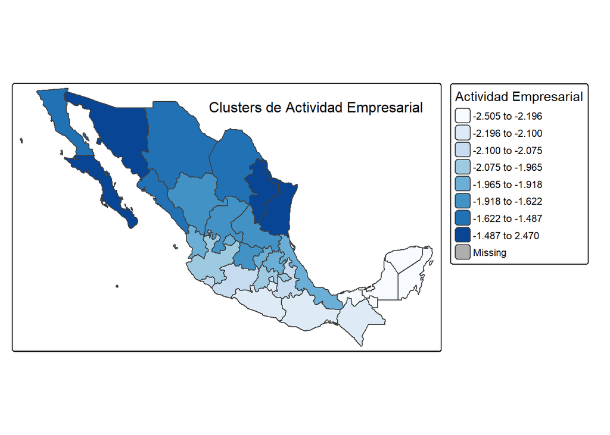

Los salarios más altos (rojo oscuro) se concentran en áreas específicas como Baja California Sur, regiones del noreste, y partes del sureste como Quintana Roo. Las regiones centrales y centro-occidente tienen salarios medios-bajos.

```r
tm_shape(state_geodata) +
  tm_polygons(col = "sp_lag_real_wage", palette="OrRd", style="quantile", n=8, title="Salario Real") +
  tm_layout(main.title= 'Clusters de Salario Real',  title.position = c('right', 'top'), legend.outside = TRUE, legend.outside.position = "left", title.size = 1)
```

```
## ── tmap v3 code detected ─────────────────────────────────────────────────────────────────────────────────────────────────────────────────────────────────────────────
```

[output not shown]

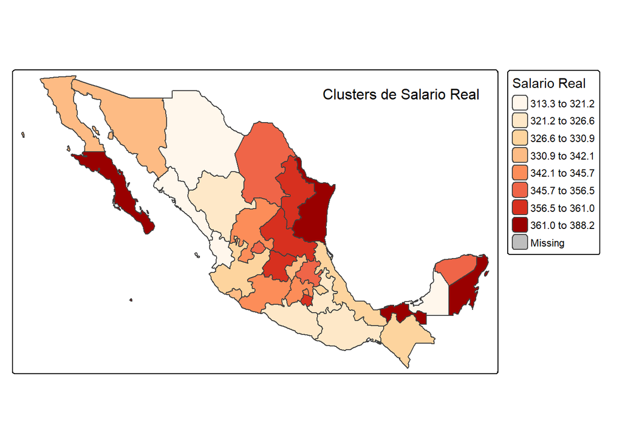

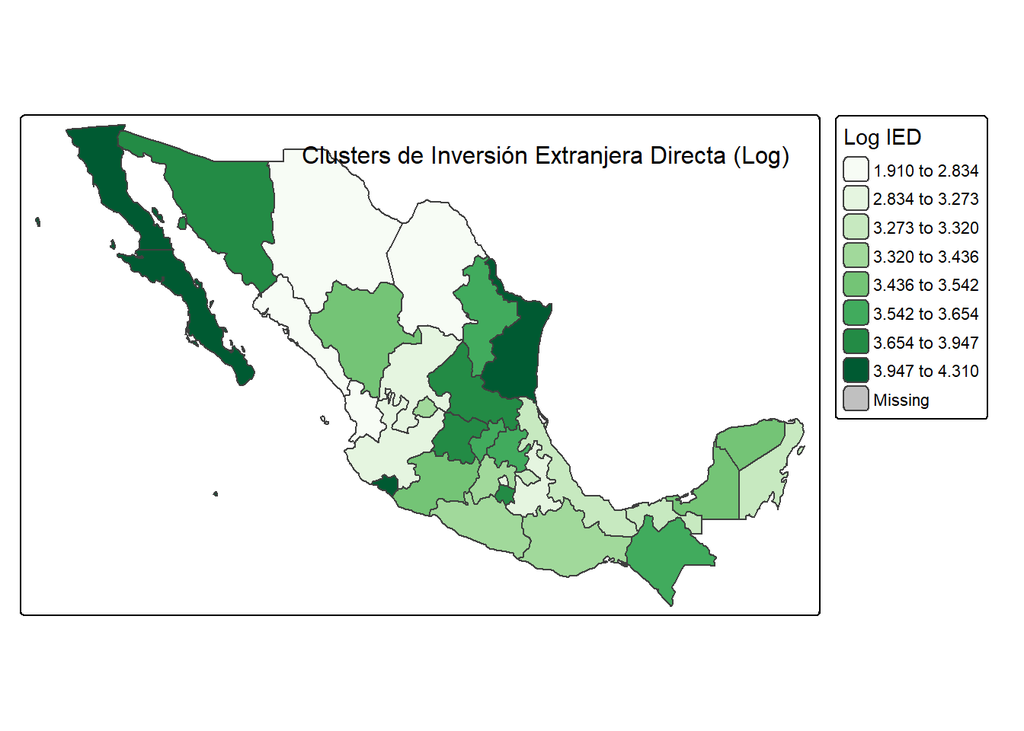

```r
tm_shape(state_geodata) +
  tm_polygons(col = "sp_lag_fdi", palette="Greens", style="quantile", n=8, title="Log IED") +
  tm_layout(main.title= 'Clusters de Inversión Extranjera Directa (Log)',  title.position = c('right', 'top'), legend.outside = TRUE, legend.outside.position = "left", title.size = 1)
```

```r
# tmap_arrange(business_lag, wage_lag, fdi_lag, ncol = 2)
```

### 1.1.7 Visualización Espacial de Clusters (Conglomerados)

Segregación en las diferentes posibilidades de agrupaciones: + No significante + HotSpots: Alto - Alto + ColdSpots: Bajo - Bajo + Atípicos: Alto - Bajo + Atípicos: Bajo - Alto

```r
sswm_a <- queen_weights(mx_state_map) # matriz de pesos espaciales estilo reina

lisa_business <- local_moran(sswm_a, state_geodata["business_activity"])
state_geodata$cluster_business <- as.factor(lisa_business$GetClusterIndicators())
levels(state_geodata$cluster_business)<-lisa_business$GetLabels()
```

Un cluster Alto-Alto (High-High) en Sonora Un cluster Bajo-Alto (Low-High) en Baja California Sur Un cluster Bajo-Bajo (Low-Low) en la península de Yucatán El resto del país muestra patrones no significativos estadísticamente

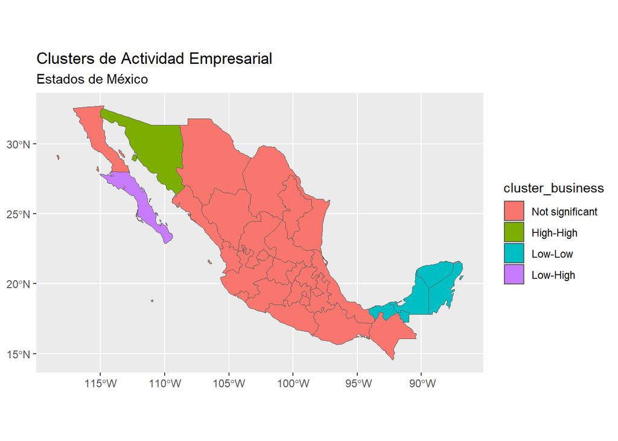

```r
ggplot(data=state_geodata) +
  geom_sf(aes(fill=cluster_business)) +
  ggtitle(label = "Clusters de Actividad Empresarial", subtitle = "Estados de México")
```

```r
lisa_wage <- local_moran(sswm_a, state_geodata["real_wage"])
state_geodata$cluster_wage <- as.factor(lisa_wage$GetClusterIndicators())
levels(state_geodata$cluster_wage)<-lisa_wage$GetLabels()
```

Todo el país aparece como “Not significant”, indicando ausencia de agrupaciones espaciales estadísticamente significativas para salarios reales

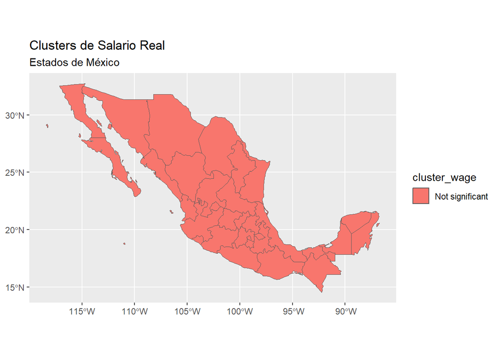

```r
ggplot(data=state_geodata) +
  geom_sf(aes(fill=cluster_wage)) +
  ggtitle(label = "Clusters de Salario Real", subtitle = "Estados de México")
```

```r
lisa_fdi <- local_moran(sswm_a, state_geodata["log_new_fdi_real_mxn"])
state_geodata$cluster_fdi <- as.factor(lisa_fdi$GetClusterIndicators())
levels(state_geodata$cluster_fdi)<-lisa_fdi$GetLabels()
```

- Un cluster Alto-Alto en Tamaulipas.
- Un cluster Bajo-Bajo en Nayarit.
- El resto del país no muestra patrones espaciales significativos.

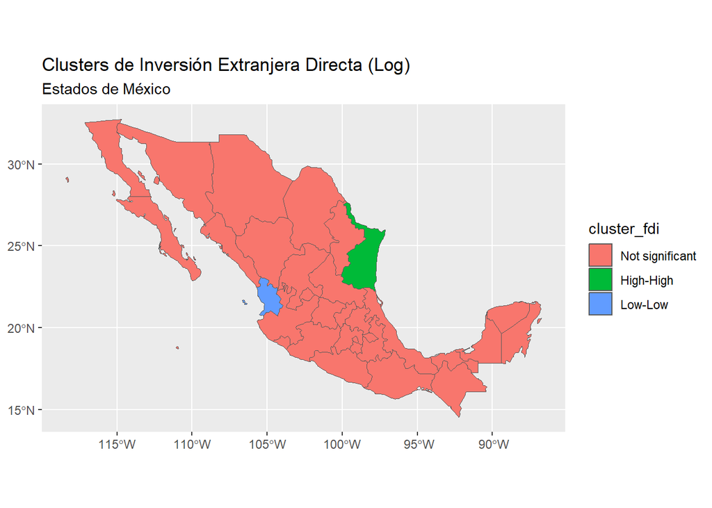

```r
ggplot(data=state_geodata) +
  geom_sf(aes(fill=cluster_fdi)) +
  ggtitle(label = "Clusters de Inversión Extranjera Directa (Log)", subtitle = "Estados de México")
```

### 1.1.8 Scatterplots

**Actividad Empresarial vs Salario Real**

No se observa una relación clara entre actividad empresarial y salario real. La línea de tendencia es casi plana, indicando poca o nula correlación entre estas variables.

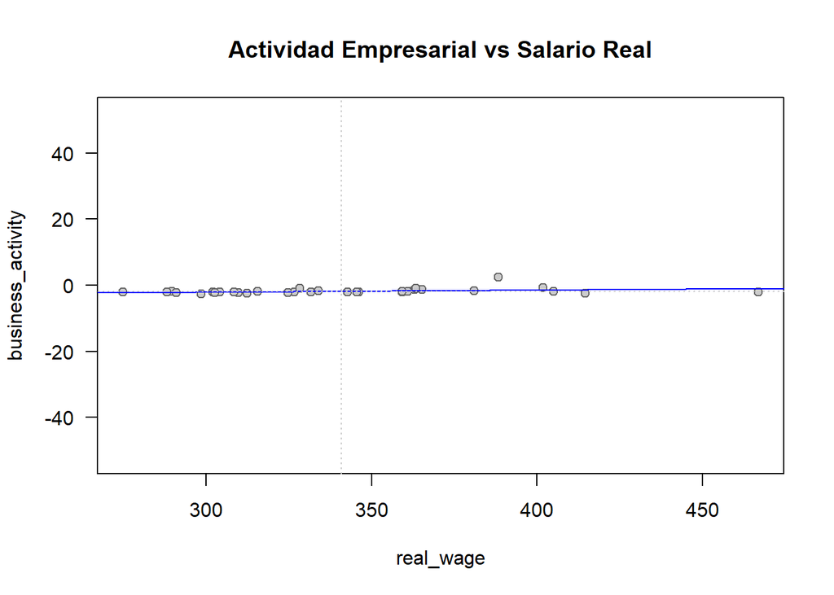

```r
# Create a regression model
M1 <- lm(business_activity ~ real_wage, state_geodata)

# Plot the data
plot(business_activity ~ real_wage, state_geodata, pch=21, asp=1, las=1, col = "grey40", bg="grey80", main="Actividad Empresarial vs Salario Real")
abline(M1, col="blue")
abline(v = mean(state_geodata$real_wage), lty=3, col = "grey80")
abline(h = mean(state_geodata$business_activity), lty=3, col = "grey80")
```

**Actividad Empresarial vs IED**

La dispersión de los puntos sugiere que la relación, aunque positiva, no es fuertemente predictiva, existiendo otros factores que influyen en la actividad empresarial además de la inversión extranjera directa.

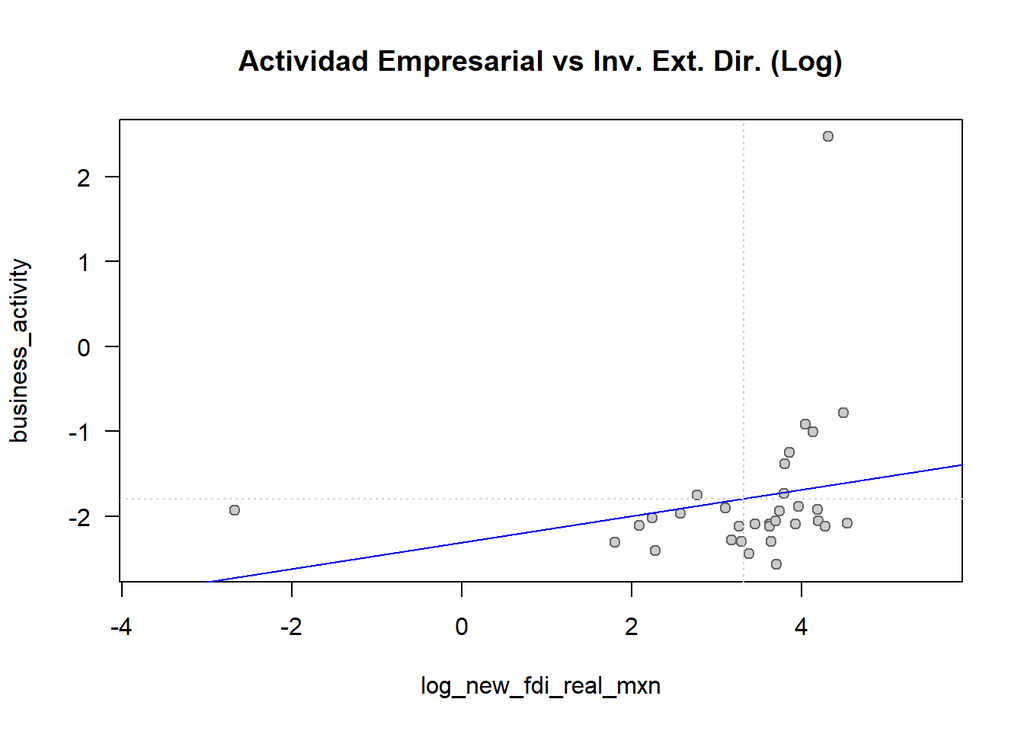

```r
# Create a regression model
M2 <- lm(business_activity ~ log_new_fdi_real_mxn, state_geodata)

# Plot the data
plot(business_activity ~ log_new_fdi_real_mxn, state_geodata, pch=21, asp=1, las=1, col = "grey40", bg="grey80", main="Actividad Empresarial vs Inv. Ext. Dir. (Log)")
abline(M2, col="blue")
abline(v = mean(state_geodata$log_new_fdi_real_mxn), lty=3, col = "grey80")
abline(h = mean(state_geodata$business_activity), lty=3, col = "grey80")
```

**Salario Real vs IED**

Hay una relación positiva entre la inversión extranjera directa (log) y el salario real. A mayor inversión, mayor salario real. Sin embargo, hay valores atípicos (outliers) que podrían estar afectando la visualización, especialmente hacia la izquierda.

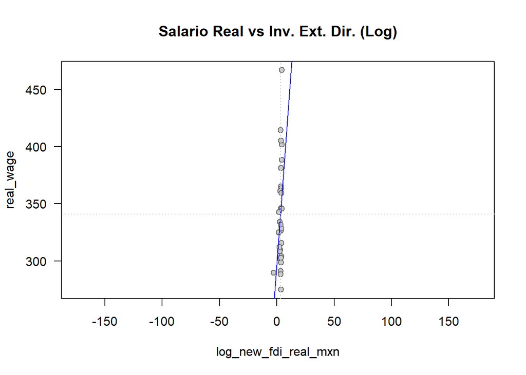

```r
# Create a regression model
M3 <- lm(real_wage ~ log_new_fdi_real_mxn, state_geodata)

# Plot the data
plot(real_wage ~ log_new_fdi_real_mxn, state_geodata, pch=21, asp=1, las=1, col = "grey40", bg="grey80", main="Salario Real vs Inv. Ext. Dir. (Log)")
abline(M3, col="blue")
abline(v = mean(state_geodata$log_new_fdi_real_mxn), lty=3, col = "grey80")
abline(h = mean(state_geodata$real_wage), lty=3, col = "grey80")
```

## 1.2 Modelos de Regresión

Cargamos algunas libererías adicionales que se utilizan para el análisis de relaciones espaciales:

```r
library(spatialreg)
library(stargazer)
```

En esta sección exploraremos diferentes modelos espaciales para entender mejor cómo la Actividad Empresarial y el Salario Real se relacionan entre sí considerando su distribución geográfica.

### 1.2.1 Modelos de Regresión Espacial

Los modelos espaciales nos permiten incorporar la dependencia espacial en nuestro análisis. Utilizaremos varios tipos de modelos:

1. SAR (Spatial AutoRegressive Model): Incorpora la dependencia espacial en la variable respuesta
2. SEM (Spatial Error Model): Incorpora la dependencia espacial en los términos de error
3. SDM (Spatial Durbin Model): Considera tanto la dependencia espacial en la variable respuesta como en las variables explicativas

Estos modelos nos ayudarán a entender mejor cómo las variables se relacionan espacialmente y si existen efectos de vecindad significativos.

Primero recordemos los modelos de regresión tradicional (no espaciales)

Resultados del modelo_a:

- Solo el salario real es estadísticamente significativo (p=0.043) con coeficiente positivo (0.011328)
- La actividad empresarial no es significativa (p=0.554)
- R² ajustado es bajo (0.122), indicando que el modelo explica poco de la variación
- F-estadístico (3.153) es marginalmente significativo (p=0.05768)
- AIC del modelo es 108.52

**Solo el salario real parece tener una relación estadísticamente significativa** con la IED en Log, pero el poder explicativo general del modelo es limitado.

```r
model_a <- lm(log_new_fdi_real_mxn ~ business_activity + real_wage, data = state_geodata)
summary(model_a)
```

```
##
## Call:
## lm(formula = log_new_fdi_real_mxn ~ business_activity + real_wage,
##     data = state_geodata)
##
## Residuals:
##     Min      1Q  Median      3Q     Max
## -5.4014 -0.3759  0.2773  0.6288  1.3363
##
## Coefficients:
##                    Estimate Std. Error t value Pr(>|t|)
## (Intercept)       -0.260323   2.034868  -0.128    0.899
## business_activity  0.155881   0.260630   0.598    0.554
## real_wage          0.011328   0.005351   2.117    0.043 *
## ---
## Signif. codes:  0 '***' 0.001 '**' 0.01 '*' 0.05 '.' 0.1 ' ' 1
##
## Residual standard error: 1.222 on 29 degrees of freedom
## Multiple R-squared:  0.1786, Adjusted R-squared:  0.122
## F-statistic: 3.153 on 2 and 29 DF,  p-value: 0.05768
```

```r
AIC(model_a)
```

```
## [1] 108.5177
```

Resultados del modelo_a2:

- R² ajustado de 0.1408 (explica ~14% de la variación)
- La variable real_wage es estadísticamente significativa (p=0.0196)
- F-estadístico (6.078) es significativo (p=0.01963)
- AIC = 106.91

Se podría considerar que esta opción es mejor, pues:

- Tiene el R² ajustado más alto
- Tiene el AIC más bajo
- Presenta el F-estadístico más significativo
- Es más parsimonioso/simple.

```r
model_a2 <- lm(log_new_fdi_real_mxn ~ real_wage, data=state_geodata)
summary(model_a2)
```

```
##
## Call:
## lm(formula = log_new_fdi_real_mxn ~ real_wage, data = state_geodata)
##
## Residuals:
##     Min      1Q  Median      3Q     Max
## -5.3698 -0.3963  0.2853  0.6025  1.3329
##
## Coefficients:
##              Estimate Std. Error t value Pr(>|t|)
## (Intercept) -0.891066   1.721536  -0.518   0.6085
## real_wage    0.012357   0.005012   2.465   0.0196 *
## ---
## Signif. codes:  0 '***' 0.001 '**' 0.01 '*' 0.05 '.' 0.1 ' ' 1
##
## Residual standard error: 1.209 on 30 degrees of freedom
## Multiple R-squared:  0.1685, Adjusted R-squared:  0.1408
## F-statistic: 6.078 on 1 and 30 DF,  p-value: 0.01963
```

```r
AIC(model_a2)
```

```
## [1] 106.91
```

Ahora buscaremos dar una mayor complejidad a los modelos previos al considerar terminos de autocorrelación espacial, es decir

#### 1.2.1.1 SAR - Spatial AutoRegressive Model

También conocido como Spatial Lag Model

- El salario real es significativo (p=0.02306) con un coeficiente de 0.0115
- La actividad empresarial no es significativa (p=0.47816)
- El parámetro espacial Rho=-0.14391 no es significativo (p=0.52875)
- AIC=110.21, mayor que el modelo no espacial (108.52)

```r
model_b <- lagsarlm(log_new_fdi_real_mxn ~ business_activity + real_wage, data = state_geodata, listw = sswm)
summary(model_b)
```

```
##
## Call:lagsarlm(formula = log_new_fdi_real_mxn ~ business_activity +
##     real_wage, data = state_geodata, listw = sswm)
##
## Residuals:
##      Min       1Q   Median       3Q      Max
## -5.37694 -0.35135  0.29414  0.64649  1.36053
##
## Type: lag
## Coefficients: (asymptotic standard errors)
##                    Estimate Std. Error z value Pr(>|z|)
## (Intercept)       0.2014125  2.0563083  0.0979  0.92197
## business_activity 0.1747270  0.2463493  0.7093  0.47816
## real_wage         0.0114949  0.0050585  2.2724  0.02306
##
## Rho: -0.14391, LR test value: 0.30593, p-value: 0.58019
## Asymptotic standard error: 0.22846
##     z-value: -0.62992, p-value: 0.52875
## Wald statistic: 0.3968, p-value: 0.52875
##
## Log likelihood: -50.10591 for lag model
## ML residual variance (sigma squared): 1.3346, (sigma: 1.1552)
## Number of observations: 32
## Number of parameters estimated: 5
## AIC: 110.21, (AIC for lm: 108.52)
## LM test for residual autocorrelation
## test value: 2.6505, p-value: 0.10352
```

```r
AIC(model_b)
```

```
## [1] 110.2118
```

```r
# ?lagsarlm
```

Ahora omitiendo de nuevo la variable de actividad empresarial

- El salario real es muy significativo (p=0.009129) con coeficiente de 0.0126
- Rho=-0.11797 no es significativo (p=0.61432)
- AIC=108.70, mayor que el modelo no espacial (106.91)

```r
model_b2 <- lagsarlm(log_new_fdi_real_mxn ~ real_wage, data = state_geodata, listw = sswm)
summary(model_b2)
```

```
##
## Call:
## lagsarlm(formula = log_new_fdi_real_mxn ~ real_wage, data = state_geodata,
##     listw = sswm)
##
## Residuals:
##      Min       1Q   Median       3Q      Max
## -5.34660 -0.43717  0.27923  0.62162  1.35241
##
## Type: lag
## Coefficients: (asymptotic standard errors)
##               Estimate Std. Error z value Pr(>|z|)
## (Intercept) -0.5750685  1.8119579 -0.3174 0.750960
## real_wage    0.0125961  0.0048313  2.6072 0.009129
##
## Rho: -0.11797, LR test value: 0.20897, p-value: 0.64758
## Asymptotic standard error: 0.23411
##     z-value: -0.50392, p-value: 0.61432
## Wald statistic: 0.25394, p-value: 0.61432
##
## Log likelihood: -50.35054 for lag model
## ML residual variance (sigma squared): 1.3574, (sigma: 1.1651)
## Number of observations: 32
## Number of parameters estimated: 4
## AIC: 108.7, (AIC for lm: 106.91)
## LM test for residual autocorrelation
## test value: 2.3963, p-value: 0.12163
```

```r
AIC(model_b2)
```

```
## [1] 108.7011
```

Esencial, incluir la matriz de conectividad espacial dada en el parámetro ‘listw’ por el objeto previamente calculado con el nombre de ‘sswm’

#### 1.2.1.2 SEM - Spatial Error Model

Modelo de Error Espacial

- El salario real es significativo (p=0.01361) con coeficiente de 0.0119
- La actividad empresarial no es significativa (p=0.33005)
- Lambda=-0.31006 no es significativo (p=0.20237)
- AIC=109.33, mayor que el modelo no espacial (108.52)

```r
model_c <- errorsarlm(log_new_fdi_real_mxn ~ business_activity + real_wage, data = state_geodata, listw = sswm)
summary(model_c)
```

```
##
## Call:errorsarlm(formula = log_new_fdi_real_mxn ~ business_activity +
##     real_wage, data = state_geodata, listw = sswm)
##
## Residuals:
##      Min       1Q   Median       3Q      Max
## -5.27954 -0.36631  0.22406  0.72099  1.41957
##
## Type: error
## Coefficients: (asymptotic standard errors)
##                     Estimate Std. Error z value Pr(>|z|)
## (Intercept)       -0.3296991  1.8136385 -0.1818  0.85575
## business_activity  0.2142101  0.2199249  0.9740  0.33005
## real_wage          0.0118609  0.0048073  2.4673  0.01361
##
## Lambda: -0.31006, LR test value: 1.1854, p-value: 0.27626
## Asymptotic standard error: 0.24321
##     z-value: -1.2748, p-value: 0.20237
## Wald statistic: 1.6252, p-value: 0.20237
##
## Log likelihood: -49.66617 for error model
## ML residual variance (sigma squared): 1.2747, (sigma: 1.129)
## Number of observations: 32
## Number of parameters estimated: 5
## AIC: 109.33, (AIC for lm: 108.52)
```

```r
AIC(model_c)
```

```
## [1] 109.3323
```

```r
# ?errorsarlm
```

Omitiendo la variable de actividad empresarial

- El salario real es muy significativo (p=0.004732) con coeficiente de 0.0132
- Lambda=-0.23773 no es significativo (p=0.33075)
- AIC=108.20, mayor que el modelo no espacial (106.91)

```r
model_c2 <- errorsarlm(log_new_fdi_real_mxn ~ real_wage, data = state_geodata, listw = sswm)
summary(model_c2)
```

```
##
## Call:
## errorsarlm(formula = log_new_fdi_real_mxn ~ real_wage, data = state_geodata,
##     listw = sswm)
##
## Residuals:
##      Min       1Q   Median       3Q      Max
## -5.25499 -0.51645  0.26564  0.65625  1.38180
##
## Type: error
## Coefficients: (asymptotic standard errors)
##               Estimate Std. Error z value Pr(>|z|)
## (Intercept) -1.1595300  1.5976930 -0.7258 0.467990
## real_wage    0.0131676  0.0046615  2.8247 0.004732
##
## Lambda: -0.23773, LR test value: 0.70964, p-value: 0.39956
## Asymptotic standard error: 0.24443
##     z-value: -0.9726, p-value: 0.33075
## Wald statistic: 0.94594, p-value: 0.33075
##
## Log likelihood: -50.1002 for error model
## ML residual variance (sigma squared): 1.3225, (sigma: 1.15)
## Number of observations: 32
## Number of parameters estimated: 4
## AIC: 108.2, (AIC for lm: 106.91)
```

```r
AIC(model_c2)
```

```
## [1] 108.2004
```

Igual que en el modelo SAR es esencial, incluir la matriz de conectividad espacial dada en el parámetro ‘listw’ por el objeto previamente calculado con el nombre de ‘sswm’

#### 1.2.1.3 SDM - Spatial Durbin Model

- El salario real es significativo (p=0.02945) con coeficiente de 0.0107
- Ninguna otra variable ni efectos espaciales son significativos
- AIC=112.10, más alto de todos los modelos

```r
model_d <- lagsarlm(log_new_fdi_real_mxn ~ business_activity + real_wage, data = state_geodata, listw = sswm, type="mixed")
summary(model_d)
```

```
##
## Call:lagsarlm(formula = log_new_fdi_real_mxn ~ business_activity +
##     real_wage, data = state_geodata, listw = sswm, type = "mixed")
##
## Residuals:
##       Min        1Q    Median        3Q       Max
## -5.182230 -0.320974  0.092534  0.701528  1.371575
##
## Type: mixed
## Coefficients: (asymptotic standard errors)
##                         Estimate Std. Error z value Pr(>|z|)
## (Intercept)           -3.5788596  4.3281057 -0.8269  0.40830
## business_activity      0.1583358  0.2413201  0.6561  0.51174
## real_wage              0.0107306  0.0049281  2.1774  0.02945
## lag.business_activity  0.1184826  0.2594673  0.4566  0.64793
## lag.real_wage          0.0138127  0.0118607  1.1646  0.24419
##
## Rho: -0.29145, LR test value: 1.1005, p-value: 0.29416
## Asymptotic standard error: 0.24281
##     z-value: -1.2003, p-value: 0.23001
## Wald statistic: 1.4408, p-value: 0.23001
##
## Log likelihood: -49.04928 for mixed model
## ML residual variance (sigma squared): 1.2299, (sigma: 1.109)
## Number of observations: 32
## Number of parameters estimated: 7
## AIC: 112.1, (AIC for lm: 111.2)
## LM test for residual autocorrelation
## test value: 2.3719, p-value: 0.12354
```

```r
AIC(model_d)
```

```
## [1] 112.0986
```

Omitiendo la variable de actividad empresarial

- El salario real es significativo (p=0.01387) con coeficiente de 0.0117
- El rezago espacial del salario real no es significativo (p=0.14714)
- AIC=108.85, mayor que el modelo no espacial

```r
model_d2 <- lagsarlm(log_new_fdi_real_mxn ~ real_wage, data = state_geodata, listw = sswm, type="mixed")
summary(model_d2)
```

```
##
## Call:
## lagsarlm(formula = log_new_fdi_real_mxn ~ real_wage, data = state_geodata,
##     listw = sswm, type = "mixed")
##
## Residuals:
##      Min       1Q   Median       3Q      Max
## -5.11767 -0.41400  0.16589  0.70851  1.32032
##
## Type: mixed
## Coefficients: (asymptotic standard errors)
##                 Estimate Std. Error z value Pr(>|z|)
## (Intercept)   -5.2432077  3.7529298 -1.3971  0.16238
## real_wage      0.0117232  0.0047644  2.4606  0.01387
## lag.real_wage  0.0159077  0.0109731  1.4497  0.14714
##
## Rho: -0.25619, LR test value: 0.8638, p-value: 0.35268
## Asymptotic standard error: 0.24274
##     z-value: -1.0554, p-value: 0.29123
## Wald statistic: 1.1139, p-value: 0.29123
##
## Log likelihood: -49.42272 for mixed model
## ML residual variance (sigma squared): 1.2648, (sigma: 1.1246)
## Number of observations: 32
## Number of parameters estimated: 5
## AIC: 108.85, (AIC for lm: 107.71)
## LM test for residual autocorrelation
## test value: 2.4381, p-value: 0.11842
```

```r
AIC(model_d2)
```

```
## [1] 108.8454
```

Igual que en los modelo SAR y SEM es esencial, incluir la matriz de conectividad espacial dada en el parámetro ‘listw’ por el objeto previamente calculado con el nombre de ‘sswm’ y aquí en particular se debe añadir el parámetro ‘type’ con valor ‘mixed’ para que en esencia mezcle los dos modelos previos (SAR y SEM).

Finalmente para generar una breve comparativa se utiliza la librería ‘stargazer’

```r
stargazer(model_a, model_b, model_c, model_d, type = "text", title="Estimated Regression Results")
```

```
##
## Estimated Regression Results
## ===============================================================================
##                                          Dependent variable:
##                       ---------------------------------------------------------
##                                         log_new_fdi_real_mxn
##                               OLS            spatial     spatial    spatial
##                                           autoregressive  error  autoregressive
##                               (1)              (2)         (3)        (4)
## -------------------------------------------------------------------------------
## business_activity            0.156            0.175       0.214      0.158
##                             (0.261)          (0.246)     (0.220)    (0.241)
##
## real_wage                   0.011**          0.011**     0.012**    0.011**
##                             (0.005)          (0.005)     (0.005)    (0.005)
##
## lag.business_activity                                                0.118
##                                                                     (0.259)
##
## lag.real_wage                                                        0.014
##                                                                     (0.012)
##
## Constant                    -0.260            0.201      -0.330      -3.579
##                             (2.035)          (2.056)     (1.814)    (4.328)
##
## -------------------------------------------------------------------------------
## Observations                  32                32         32          32
## R2                           0.179
## Adjusted R2                  0.122
## Log Likelihood                               -50.106     -49.666    -49.049
## sigma2                                        1.335       1.275      1.230
## Akaike Inf. Crit.                            110.212     109.332    112.099
## Residual Std. Error     1.222 (df = 29)
## F Statistic           3.153* (df = 2; 29)
## Wald Test (df = 1)                            0.397       1.625      1.441
## LR Test (df = 1)                              0.306       1.185      1.100
## ===============================================================================
## Note:                                               *p<0.1; **p<0.05; ***p<0.01
```

Omitiendo la variable de actividad empresarial

El modelo más parsimonioso y con mejor ajuste sigue siendo el modelo OLS simple con solo salario real (model_a2), con el AIC más bajo (106.91). Los componentes espaciales no mejoran significativamente el ajuste del modelo.

```r
stargazer(model_a2, model_b2, model_c2, model_d2, type = "text", title="Estimated Regression Results")
```

```
##
## Estimated Regression Results
## ===============================================================================
##                                         Dependent variable:
##                     -----------------------------------------------------------
##                                        log_new_fdi_real_mxn
##                             OLS             spatial     spatial     spatial
##                                          autoregressive  error   autoregressive
##                             (1)               (2)         (3)         (4)
## -------------------------------------------------------------------------------
## real_wage                 0.012**           0.013***    0.013***    0.012**
##                           (0.005)           (0.005)     (0.005)     (0.005)
##
## lag.real_wage                                                        0.016
##                                                                     (0.011)
##
## Constant                   -0.891            -0.575      -1.160      -5.243
##                           (1.722)           (1.812)     (1.598)     (3.753)
##
## -------------------------------------------------------------------------------
## Observations                 32                32          32          32
## R2                         0.168
## Adjusted R2                0.141
## Log Likelihood                              -50.351     -50.100     -49.423
## sigma2                                       1.357       1.322       1.265
## Akaike Inf. Crit.                           108.701     108.200     108.845
## Residual Std. Error   1.209 (df = 30)
## F Statistic         6.078** (df = 1; 30)
## Wald Test (df = 1)                           0.254       0.946       1.114
## LR Test (df = 1)                             0.209       0.710       0.864
## ===============================================================================
## Note:                                               *p<0.1; **p<0.05; ***p<0.01
```

### 1.2.2 Referencias para el Análisis Exploratorio de Datos Espaciales

What is exploratory data analysis? https://www.ibm.com/topics/exploratory-data-analysis

Exploratory Spatial Data Analysis https://cran.r-project.org/web/packages/geostan/vignettes/measuring-sa.html

## 1.3 Análisis Espacial de Datos Panel

Cargar algunas otras librerías adicionales

```r
library(plm)
library(splm)
library(pspatreg)
```

Leer base de datos Panel (mismas tablas de datos a través del tiempo)

```r
panel_data <- read.csv("panel_dataset.csv")
pd_frame <- pdata.frame(panel_data, index = c("state", "year"), drop.index = TRUE)
head(pd_frame)
```

|  | state_id | new_fdi | reinv_profits | intercom_acc | total_fdi | crime_rate | unemployment | employment | business_activity | real_wage | real_ave_month_income | pop_density | good_governance | ratio_public_investment | lq_primary | lq_secondary | lq_tertiary | exchange_rate | patents_rate | inpc | border_distance | college_education | new_fdi_real_mxn | log_new_fdi_real_mxn | region_a | region_b | trump_election | exports |
| --- | --- | --- | --- | --- | --- | --- | --- | --- | --- | --- | --- | --- | --- | --- | --- | --- | --- | --- | --- | --- | --- | --- | --- | --- | --- | --- | --- | --- |
| 1 | 1057 | 37.99 | 45.12 | 57.48 | 140.59 | 2.32 | 0.05 | 0.96 | -2.29 | 301.02 | 6041.94 | 199.63 | 0.16 | 0.01 | 0.17 | 1.14 | 1.02 | 10.85 | 0.45 | 62.69 | 625.59 | 0.330 | 657.392 | 2.818 | Bajio | 2 | 0 | NA |
| 2 | 1057 | 320.84 | 42.62 | 47.12 | 410.57 | 3.86 | 0.06 | 0.96 | -2.26 | 302.23 | 5812.44 | 203.13 | 0.11 | 0.02 | 0.17 | 1.16 | 1.02 | 10.85 | 0.26 | 65.05 | 625.59 | 0.348 | 5350.673 | 3.728 | Bajio | 2 | 0 | 4389841 |
| 3 | 1057 | 39.34 | 330.02 | -31.87 | 337.49 | 5.08 | 0.06 | 0.94 | -2.27 | 293.79 | 6096.76 | 206.99 | 0.10 | 0.02 | 0.18 | 1.13 | 1.03 | 13.42 | 0.86 | 69.30 | 625.59 | 0.354 | 761.927 | 2.882 | Bajio | 2 | 0 | 4456893 |
| 4 | 1057 | 470.53 | 24.51 | -152.84 | 342.21 | 5.66 | 0.07 | 0.94 | -2.27 | 297.00 | 5855.42 | 210.80 | 0.07 | 0.02 | 0.14 | 1.16 | 1.02 | 12.86 | 0.34 | 71.77 | 625.59 | 0.364 | 8433.011 | 3.926 | Bajio | 2 | 0 | 3951108 |
| 5 | 1057 | 67.03 | 102.40 | 163.73 | 333.15 | 6.23 | 0.06 | 0.93 | -2.22 | 295.75 | 5462.77 | 214.28 | 0.12 | 0.01 | 0.13 | 1.16 | 1.02 | 12.39 | 0.58 | 74.93 | 625.59 | 0.377 | 1108.146 | 3.045 | Bajio | 2 | 0 | 5647929 |
| 6 | 1057 | 3.66 | 235.26 | -2.11 | 236.81 | 8.59 | 0.05 | 0.94 | -2.16 | 299.96 | 5692.78 | 217.63 | 0.11 | 0.01 | 0.22 | 1.11 | 1.03 | 13.77 | 0.33 | 77.79 | 625.59 | 0.395 | 64.702 | 1.811 | Bajio | 2 | 0 | 6051640 |

```r
# ?pdata.frame
```

Agregar lag espacial (importante incluir matriz de conectividad espacial, previamente calculada ‘sswm’) de algunas de las variables independientes (real_wage)

```r
sp_lag_wage <- slag(pd_frame$real_wage, sswm)
```

Definir el modelo a ser ajustado

```r
panel_model <- log_new_fdi_real_mxn ~ business_activity + real_wage + sp_lag_wage
```

Ajustar modelo

- Ninguna variable es estadísticamente significativa
- R² es extremadamente bajo (0.0018)
- R² ajustado es negativo (-0.104)
- F-estadístico (0.28401) no es significativo (p=0.83695)

```r
non_spatial_panel_model_a <- plm(panel_model, data = pd_frame, model = "within", effect = "twoways")
summary(non_spatial_panel_model_a)
```

```
## Twoways effects Within Model
##
## Call:
## plm(formula = panel_model, data = pd_frame, effect = "twoways",
##     model = "within")
##
## Balanced Panel: n = 32, T = 16, N = 512
##
## Residuals:
##      Min.   1st Qu.    Median   3rd Qu.      Max.
## -7.391754 -0.254494  0.097511  0.561494  3.424783
##
## Coefficients:
##                     Estimate Std. Error t-value Pr(>|t|)
## business_activity  0.1233996  0.8333431  0.1481   0.8823
## real_wage          0.0017942  0.0064412  0.2785   0.7807
## sp_lag_wage       -0.0121686  0.0140804 -0.8642   0.3879
##
## Total Sum of Squares:    795.32
## Residual Sum of Squares: 793.85
## R-Squared:      0.0018408
## Adj. R-Squared: -0.10402
## F-statistic: 0.28401 on 3 and 462 DF, p-value: 0.83695
```

Dado los malos resultados, se inteta ajustar otro modelo con efectos aleatorios

- real_wage es estadísticamente significativa (p=0.01545) con coeficiente positivo.
- business_activity y sp_lag_wage no son significativas.
- R² es bajo (0.014) pero mejor que el modelo de efectos fijos.
- Chi-cuadrado marginalmente significativo (p=0.068216).

Este modelo de efectos aleatorios es mejor que el anterior de efectos fijos, con el salario real emergiendo nuevamente como la única variable significativa. Sin embargo, su capacidad explicativa sigue siendo limitada en comparación con los modelos transversales anteriores.

```r
non_spatial_panel_model_b <- plm(panel_model, data = pd_frame, model = "random", effect = "twoways")
summary(non_spatial_panel_model_b)
```

```
## Twoways effects Random Effect Model
##    (Swamy-Arora's transformation)
##
## Call:
## plm(formula = panel_model, data = pd_frame, effect = "twoways",
##     model = "random")
##
## Balanced Panel: n = 32, T = 16, N = 512
##
## Effects:
##                  var std.dev share
## idiosyncratic 1.7183  1.3108 0.749
## individual    0.2255  0.4748 0.098
## time          0.3500  0.5916 0.153
## theta: 0.432 (id) 0.6353 (time) 0.3897 (total)
##
## Residuals:
##      Min.   1st Qu.    Median   3rd Qu.      Max.
## -7.613104 -0.059924  0.233447  0.520307  2.364720
##
## Coefficients:
##                      Estimate  Std. Error z-value Pr(>|z|)
## (Intercept)        1.66512229  1.45191467  1.1468  0.25145
## business_activity  0.06565837  0.12083934  0.5434  0.58689
## real_wage          0.00569487  0.00235158  2.4217  0.01545 *
## sp_lag_wage       -0.00041863  0.00374539 -0.1118  0.91100
## ---
## Signif. codes:  0 '***' 0.001 '**' 0.01 '*' 0.05 '.' 0.1 ' ' 1
##
## Total Sum of Squares:    881.99
## Residual Sum of Squares: 869.81
## R-Squared:      0.013819
## Adj. R-Squared: 0.0079952
## Chisq: 7.11847 on 3 DF, p-value: 0.068216
```

### 1.3.1 Hausman Test

```r
phtest(non_spatial_panel_model_a, non_spatial_panel_model_b) # p-value is larger than 5% so we do consider RE.
```

```
##
##  Hausman Test
##
## data:  panel_model
## chisq = 1.291, df = 3, p-value = 0.7313
## alternative hypothesis: one model is inconsistent
```

Ahora procedemos a estimar un modelo de regresión de panel espacial mediante máxima Verosimilitud

**Modelo de panel espacial con efectos fijos (spatial_panel_fe):**

```r
spatial_panel_fe <- spml(panel_model, panel_data, index = c("state","year"), sswm, model= "within", effect= "time", spatial.error = "none", lag=TRUE)  # spatial autogressive
summary(spatial_panel_fe)
```

```
## Spatial panel fixed effects lag model
##
##
## Call:
## spml(formula = panel_model, data = panel_data, index = c("state",
##     "year"), listw = sswm, model = "within", effect = "time",
##     lag = TRUE, spatial.error = "none")
##
## Residuals:
##     Min.  1st Qu.   Median  3rd Qu.     Max.
## -7.29530 -0.22449  0.18671  0.55806  2.87855
##
## Spatial autoregressive coefficient:
##         Estimate Std. Error t-value Pr(>|t|)
## lambda -0.082350   0.060436 -1.3626    0.173
##
## Coefficients:
##                    Estimate Std. Error t-value  Pr(>|t|)
## business_activity 0.0601321  0.0718886  0.8365    0.4029
## real_wage         0.0065110  0.0014820  4.3933 1.116e-05 ***
## sp_lag_wage       0.0014748  0.0024170  0.6102    0.5418
## ---
## Signif. codes:  0 '***' 0.001 '**' 0.01 '*' 0.05 '.' 0.1 ' ' 1
```

```r
# ?spml
```

**Modelo autorregresivo espacial (SAR):**

- Rho (coeficiente espacial): 0.2138, altamente significativo (p<0.0001)
- real_wage altamente significativo (p=0.0002) con coeficiente 0.0057
- Las otras variables no son significativas
- AIC: 915.394, BIC: 936.586

```r
sar_panel_model <- pspatfit(formula = panel_model, data = panel_data, listw = sswm, demean = FALSE, eff_demean = "time", type = "sar", index = c("state", "year")) # spatial autoregressive
```

```
##
## Fitting Model...
```

```
##
##  Time to fit the model:  0.31 seconds
```

```r
summary(sar_panel_model)
```

```
##
##  Call
## pspatfit(formula = panel_model, data = panel_data, listw = sswm,
##     type = "sar", demean = FALSE, eff_demean = "time", index = c("state",
##         "year"))
##
##  Parametric Terms
##                      Estimate Std. Error t value  Pr(>|t|)
## (Intercept)        1.3394081  0.8783507  1.5249 0.1279044
## business_activity  0.0523019  0.0775719  0.6742 0.5004673
## real_wage          0.0057189  0.0015358  3.7236 0.0002184 ***
## sp_lag_wage       -0.0016323  0.0023039 -0.7085 0.4789703
## rho                0.2138420  0.0536794  3.9837  7.78e-05 ***
## ---
## Signif. codes:  0 '***' 0.001 '**' 0.01 '*' 0.05 '.' 0.1 ' ' 1
##
##  Goodness-of-Fit
##
##  EDF Total:      5
##  Sigma: 1.49757
##  AIC:  915.394
##  BIC:  936.586
```

```r
# ?pspatfit
```

**Modelo de panel espacial con efectos aleatorios (spatial_panel_re):**

- Lambda: 0.2625, altamente significativo (p<0.0001)
- real_wage significativo (p=0.02279) con coeficiente 0.0051
- Phi (varianza de error): 0.115, significativo (p=0.01356)

```r
spatial_panel_re <- spml(panel_model, data = panel_data, index = c("state","year"), sswm, model="random", spatial.error="none", lag=TRUE) # spatial autoregressive
summary(spatial_panel_re)
```

```
## ML panel with spatial lag, random effects
##
## Call:
## spreml(formula = formula, data = data, index = index, w = listw2mat(listw),
##     w2 = listw2mat(listw2), lag = lag, errors = errors, cl = cl)
##
## Residuals:
##    Min. 1st Qu.  Median    Mean 3rd Qu.    Max.
##  -7.233   0.772   1.187   0.844   1.508   2.410
##
## Error variance parameters:
##     Estimate Std. Error t-value Pr(>|t|)
## phi 0.115026   0.046591  2.4688  0.01356 *
##
## Spatial autoregressive coefficient:
##        Estimate Std. Error t-value  Pr(>|t|)
## lambda 0.262536   0.052721  4.9797 6.367e-07 ***
##
## Coefficients:
##                     Estimate Std. Error t-value Pr(>|t|)
## (Intercept)        1.7361847  1.1393126  1.5239  0.12754
## business_activity  0.0528342  0.1214160  0.4352  0.66345
## real_wage          0.0051183  0.0022479  2.2769  0.02279 *
## sp_lag_wage       -0.0028254  0.0031639 -0.8930  0.37186
## ---
## Signif. codes:  0 '***' 0.001 '**' 0.01 '*' 0.05 '.' 0.1 ' ' 1
```

**Modelo SARAR con efectos fijos (spatial_panel_fe con spatial.error=“b”):**

- Coeficientes espaciales no significativos
- Solo real_wage significativo (p<0.0001) con coeficiente 0.0065

```r
spatial_panel_fe <- spml(panel_model, panel_data, index = c("state","year"), sswm, model= "within", effect= "time", spatial.error = "b", lag=TRUE) # spatial autoregressive and error model
summary(spatial_panel_fe)
```

```
## Spatial panel fixed effects sarar model
##
##
## Call:
## spml(formula = panel_model, data = panel_data, index = c("state",
##     "year"), listw = sswm, model = "within", effect = "time",
##     lag = TRUE, spatial.error = "b")
##
## Residuals:
##     Min.  1st Qu.   Median  3rd Qu.     Max.
## -7.30164 -0.22192  0.18993  0.55975  2.92750
##
## Spatial error parameter:
##      Estimate Std. Error t-value Pr(>|t|)
## rho -0.042605   2.301090 -0.0185   0.9852
##
## Spatial autoregressive coefficient:
##         Estimate Std. Error t-value Pr(>|t|)
## lambda -0.044003   2.300979 -0.0191   0.9847
##
## Coefficients:
##                    Estimate Std. Error t-value  Pr(>|t|)
## business_activity 0.0608825  0.0719465  0.8462    0.3974
## real_wage         0.0065003  0.0016395  3.9648 7.345e-05 ***
## sp_lag_wage       0.0011527  0.0163115  0.0707    0.9437
## ---
## Signif. codes:  0 '***' 0.001 '**' 0.01 '*' 0.05 '.' 0.1 ' ' 1
```

### 1.3.2 Spatial Hausman Test

```r
sphtest(spatial_panel_re, spatial_panel_fe)
```

```
##
##  Hausman test for spatial models
##
## data:  formula
## chisq = 0.4475, df = 3, p-value = 0.9303
## alternative hypothesis: one model is inconsistent
```

### 1.3.3 Regresión Espacial Ponderada (GWR - Geographically Weighted Regresion)

Adaptando el ejemplo de los Estados de México con GWR.

Primero es necesario transformar tu base de datos a un ‘SpatialPolygonsDataFrame’ (SPDF)

```r
class(state_geodata)
```

```
## [1] "sf"         "data.frame"
```

```r
state_geodataSPDF <- as(state_geodata, "Spatial")
class(state_geodataSPDF)
```

```
## [1] "SpatialPolygonsDataFrame"
## attr(,"package")
## [1] "sp"
```

Ahora, con el objeto SPDF se puede generar un kernel adaptativo

```r
bw1 <- bw.gwr(log_new_fdi_real_mxn ~ business_activity + real_wage, approach = "AIC", adaptive = T, data = state_geodataSPDF)
```

```
## Adaptive bandwidth (number of nearest neighbours): 27 AICc value: 116.7448
## Adaptive bandwidth (number of nearest neighbours): 25 AICc value: 119.0958
## Adaptive bandwidth (number of nearest neighbours): 30 AICc value: 114.5832
## Adaptive bandwidth (number of nearest neighbours): 30 AICc value: 114.5832
```

Ya que se tiene el kernel a utilizar, entonces este se pasa como parámetro del comando ‘gwr’ que sirve para ajustar el modelo de Regresión Espacial Ponderada (GWR)

- Los coeficientes varían considerablemente según la ubicación geográfica:
  - Intercepto: varía desde -29.93 hasta 63.57 (global: -0.26)
  - Business activity: varía desde -12.18 hasta 31.12 (global: 0.16)
  - Real wage: varía desde -0.073 hasta 0.041 (global: 0.011)

La gran variación en los coeficientes indica heterogeneidad espacial significativa, los factores que influyen en la IED tienen efectos diferentes según la región.

En algunas regiones, el salario real tiene impacto negativo, mientras que en otras tiene impacto positivo, sugiriendo que la relación entre salarios e IED es compleja y depende del contexto geográfico.

```r
gwrG <- gwr(log_new_fdi_real_mxn ~ business_activity + real_wage, bandwidth = bw1, gweight = gwr.Gauss, data = state_geodataSPDF, hatmatrix = T)
gwrG
```

```
## Call:
## gwr(formula = log_new_fdi_real_mxn ~ business_activity + real_wage,
##     data = state_geodataSPDF, bandwidth = bw1, gweight = gwr.Gauss,
##     hatmatrix = T)
## Kernel function: gwr.Gauss
## Fixed bandwidth: 30
## Summary of GWR coefficient estimates at data points:
```

```
##                          Min.     1st Qu.      Median     3rd Qu.        Max.
## X.Intercept.      -29.9276093 -10.6086199   5.8164281  33.4136571  63.5745053
## business_activity -12.1762238  -5.2446711   0.4736603  13.1708214  31.1196366
## real_wage          -0.0725161  -0.0014125   0.0069203   0.0123294   0.0408589
##                    Global
## X.Intercept.      -0.2603
## business_activity  0.1559
## real_wage          0.0113
## Number of data points: 32
## Effective number of parameters (residual: 2traceS - traceS'S): NA
## Effective degrees of freedom (residual: 2traceS - traceS'S): NA
## Sigma (residual: 2traceS - traceS'S): NA
## Effective number of parameters (model: traceS): NA
## Effective degrees of freedom (model: traceS): NA
## Sigma (model: traceS): NA
## Sigma (ML): NA
## AICc (GWR p. 61, eq 2.33; p. 96, eq. 4.21): NA
## AIC (GWR p. 96, eq. 4.22): NA
## Residual sum of squares: NA
## Quasi-global R2: NA
```

Por último se puede graficar claramente como van variando los diferentes coeficientes a través del espacio utilizando la función ‘spplot’

Intercepto (X.Intercept. aka Beta_0)

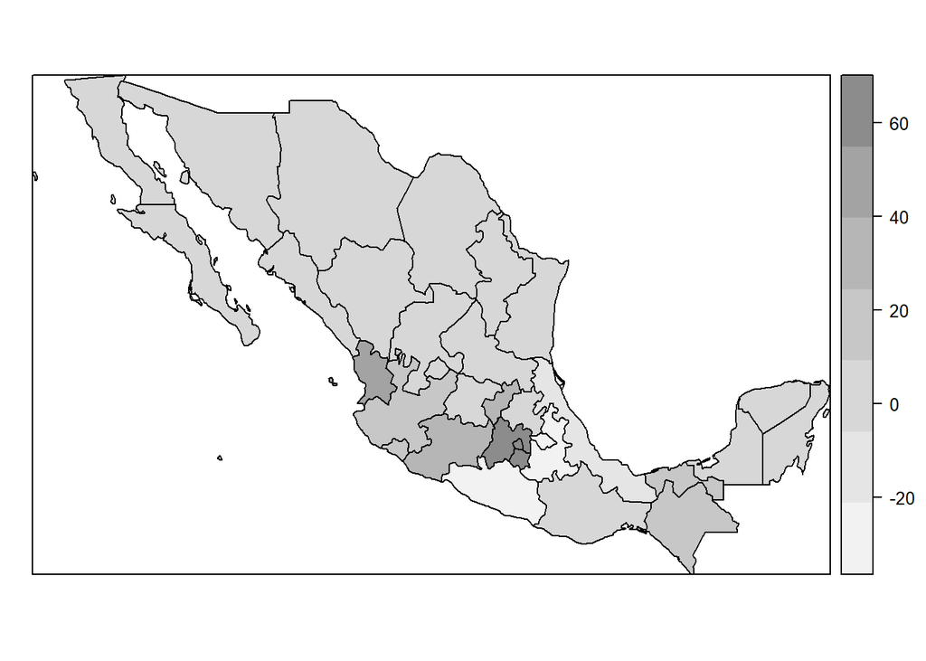

```r
spplot(gwrG$SDF, "X.Intercept.", col.regions=grey.colors(7, 0.95, 0.55, 2.2), cuts=6)
```

Actividad Empresarial (business_activity)

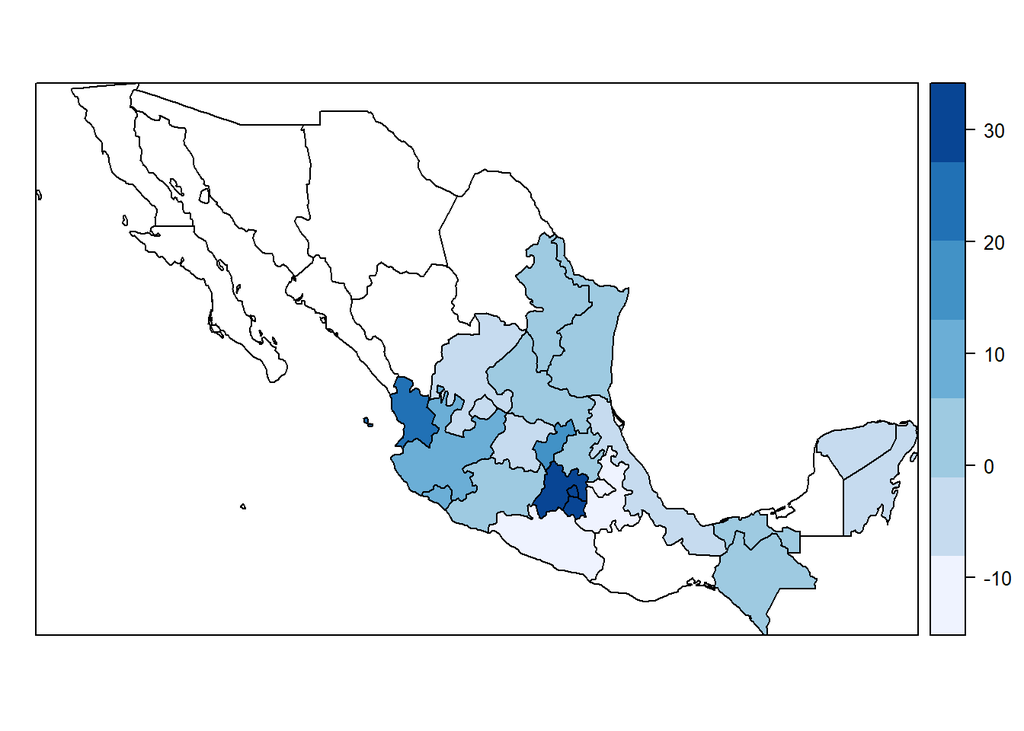

```r
spplot(gwrG$SDF, "business_activity", col.regions=brewer.pal(7,'Blues'), cuts=6)
```

Ingreso Real (real_wage)

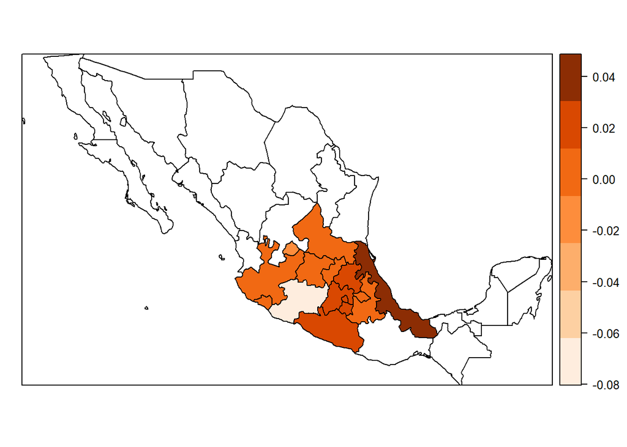

```r
spplot(gwrG$SDF, "real_wage", col.regions=brewer.pal(7, 'Oranges'), cuts=6)
```

Graficar pares de scaterplots para detectar patrones en las variaciones de los coeficientes a nivel local.

**X.Intercept. vs business_activity:**

La nube de puntos sugiere una relación positiva. A mayor valor local del intercepto, tiende a haber un coeficiente más alto de business_activity.

**X.Intercept. vs real_wage:**

**business_activity vs real_wage:**

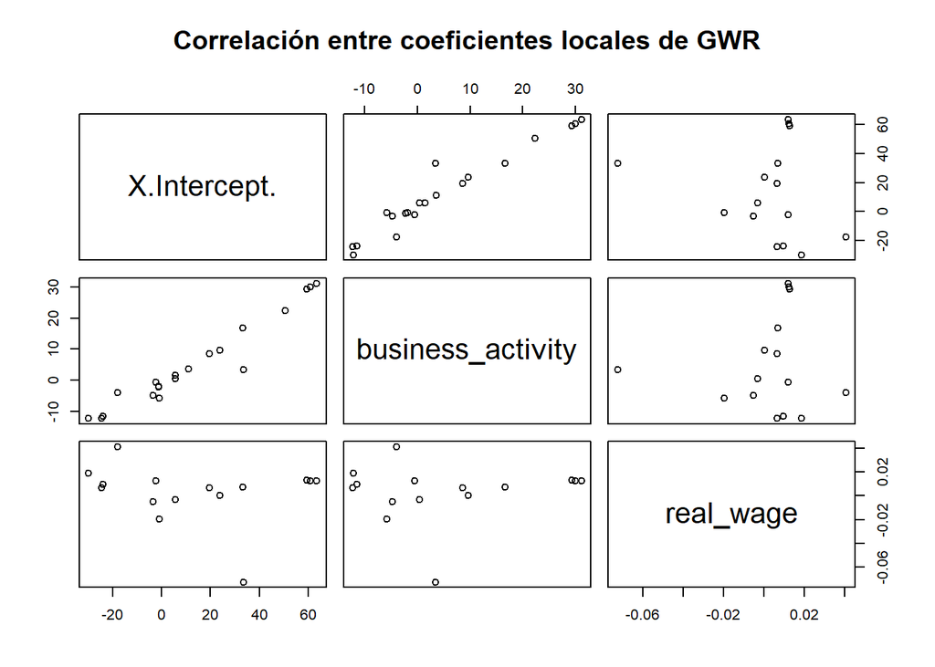

```r
pairs(as(gwrG$SDF, "data.frame")[, c("X.Intercept.", "business_activity", "real_wage")],
      main="Correlación entre coeficientes locales de GWR")
```

**Scatterplot de Moran:**

Los puntos en los cuadrantes I (superior derecho) y III (inferior izquierdo) contribuyen a la autocorrelación positiva, mientras que los puntos en los cuadrantes II y IV representan valores atípicos espaciales.

**Actividad Empresarial:**

La baja actividad empresarial tiende a agruparse, con Baja California y Baja California Sur como excepciones notables.

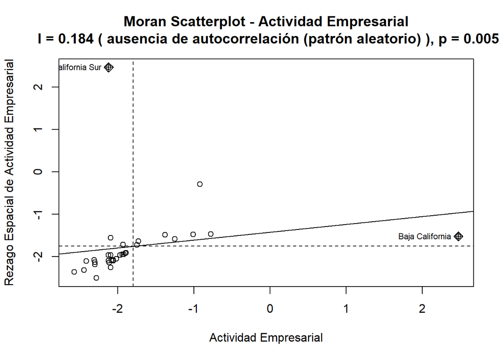

```r
# Extraer el valor I de Moran y el p-valor
moran_i_business <- round(moran_business$estimate[[1]], 3)
p_val_business <- round(moran_business$p.value, 3)

# Determinar interpretación según criterios prácticos
if (moran_i_business > 0.35) {
  interp_business <- "autocorrelación positiva (patrón clúster)"
} else if (moran_i_business < -0.35) {
  interp_business <- "autocorrelación negativa (patrón disperso)"
} else {
  interp_business <- "ausencia de autocorrelación (patrón aleatorio)"
}

# Crear el título incluyendo los valores y significancia
plot_title_business <- paste("Moran Scatterplot - Actividad Empresarial\n",
                            "I =", moran_i_business, "(", interp_business, "), p =", p_val_business)

# Generar la gráfica con el nuevo título
moran.plot(state_geodata$business_activity, sswm,
           labels=state_geodata$ADMIN_NAME,
           xlab="Actividad Empresarial",
           ylab="Rezago Espacial de Actividad Empresarial",
           main=plot_title_business)
```

**Salario Real:**

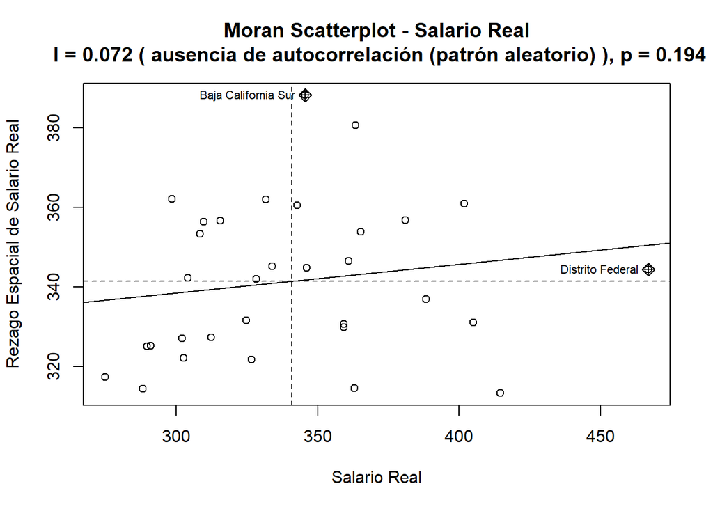

```r
# Extraer el valor I de Moran y el p-valor
moran_i_wage <- round(moran_wage$estimate[[1]], 3)
p_val_wage <- round(moran_wage$p.value, 3)

# Determinar interpretación según criterios prácticos
if (moran_i_wage > 0.35) {
  interp_wage <- "autocorrelación positiva (patrón clúster)"
} else if (moran_i_wage < -0.35) {
  interp_wage <- "autocorrelación negativa (patrón disperso)"
} else {
  interp_wage <- "ausencia de autocorrelación (patrón aleatorio)"
}

# Crear el título incluyendo los valores y significancia
plot_title_wage <- paste("Moran Scatterplot - Salario Real\n",
                         "I =", moran_i_wage, "(", interp_wage, "), p =", p_val_wage)

# Generar la gráfica con el nuevo título
moran.plot(state_geodata$real_wage, sswm,
           labels=state_geodata$ADMIN_NAME,
           xlab="Salario Real",
           ylab="Rezago Espacial de Salario Real",
           main=plot_title_wage)
```

**Inversión Extranjera Directa (IED):**

- Muchas zonas con alta IED están cerca de otras zonas con alta IED (agrupación en el cuadrante superior derecho).
- Sinaloa y Nayarit (abajo derecha) tienen alta IED, pero están rodeadas por vecinos con baja IED.
- Durango (izquierda) tiene relativamente baja IED en comparación con el promedio de sus vecinos.

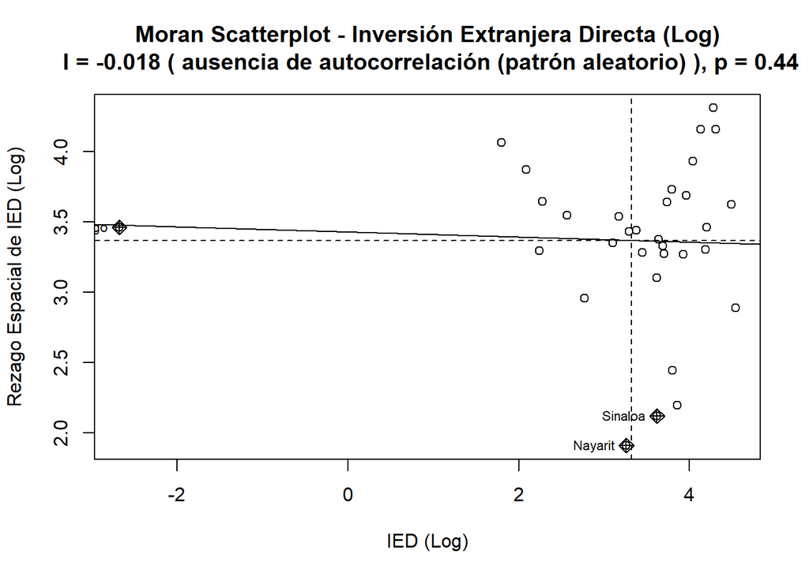

```r
# Extraer el valor I de Moran y el p-valor
moran_i_fdi <- round(moran_fdi$estimate[[1]], 3)
p_val_fdi <- round(moran_fdi$p.value, 3)

# Determinar interpretación según criterios prácticos
if (moran_i_fdi > 0.35) {
  interp_fdi <- "autocorrelación positiva (patrón clúster)"
} else if (moran_i_fdi < -0.35) {
  interp_fdi <- "autocorrelación negativa (patrón disperso)"
} else {
  interp_fdi <- "ausencia de autocorrelación (patrón aleatorio)"
}

# Crear el título incluyendo los valores y significancia
plot_title_fdi <- paste("Moran Scatterplot - Inversión Extranjera Directa (Log)\n",
                       "I =", moran_i_fdi, "(", interp_fdi, "), p =", p_val_fdi)

# Generar la gráfica con el nuevo título
moran.plot(state_geodata$log_new_fdi_real_mxn, sswm,
           labels=state_geodata$ADMIN_NAME,
           xlab="IED (Log)",
           ylab="Rezago Espacial de IED (Log)",
           main=plot_title_fdi)
```